# Clustering Techniques

## Part I: Research Question

Can we accurately predict and identify the principal variables of the customers using kmeans clustering?

We will answer this question using k-means.

The goal of this data analysis is to find if we can identify the principal variables of the customers through kmeans clustering. Another goal of K-means is to find the optimal number of clusters.

## Part II: Method Justification

K-means clustering is a form of unsupervised learning. It creates 'K' clusters over the data and compares them. This divides the data into different clusters, with data sharing similar characteristcs being clustered together. This will allow a company to find the data that has similarities with variables of the customers, so we can find the principal variables of the customers.

One assumption of K-means clustering is that the data is normalized, so before running and tests, we will need to normalize the data and prepare it for analysis.

## Part III: Data Preparation

One data preprocessing goal for this analysis will be to scale and normalize the data. This will give us more accurate results in our analysis.

The initial variables we will use are Churn, which is categorical, and Age, mothly charge, bandwidth, and tenure, which are all continuous

Preparing the data for analysis:

Data preparation will consist of cleaning up bad data, such as replacing nulls, removing duplicated rows, etc. We will also convert categorical variables to numerical so we can run linear regression. Finally all data will be normalized.

```python
# Importing packages to be used
import numpy as np
# numpy for data analysis functionality
import pandas as pd
# pandas for dataframes
from sklearn.cluster import KMeans, k_means
# Kmeans classifier
# Import ElbowVisualizer
from yellowbrick.cluster import KElbowVisualizer
import matplotlib.pyplot as plt
%matplotlib inline
# matplotlib for plotting
import seaborn as sns
# seaborn for extra plotting functionality
```

```python
# Importing the data
df = pd.read_csv('Churn Data\churn_clean.csv')
```

```python
# Checking for null values
df.isna().any()
```

```
CaseOrder               False
Customer_id             False
Interaction             False
UID                     False
City                    False
State                   False
County                  False
Zip                     False
Lat                     False
Lng                     False
Population              False
Area                    False
TimeZone                False
Job                     False
Children                False
Age                     False
Income                  False
Marital                 False
Gender                  False
Churn                   False
Outage_sec_perweek      False
Email                   False
Contacts                False
Yearly_equip_failure    False
Techie                  False
Contract                False
Port_modem              False
Tablet                  False
InternetService         False
Phone                   False
Multiple                False
OnlineSecurity          False
OnlineBackup            False
DeviceProtection        False
TechSupport             False
StreamingTV             False
StreamingMovies         False
PaperlessBilling        False
PaymentMethod           False
Tenure                  False
MonthlyCharge           False
Bandwidth_GB_Year       False
Item1                   False
Item2                   False
Item3                   False
Item4                   False
Item5                   False
Item6                   False
Item7                   False
Item8                   False
dtype: bool
```

These are all false, meaning there are no null values

```python
# Checking for duplicates
df.duplicated().any()
```

```
False
```

False, meaning there are no duplicates

```python
# Creating new dataframe with only the values we need
newdf = df[['Age', 'MonthlyCharge', 'Bandwidth_GB_Year','Tenure','Churn']].copy()
```

```python
newdf
```

|  | Age | MonthlyCharge | Bandwidth_GB_Year | Tenure | Churn |
| --- | --- | --- | --- | --- | --- |
| 0 | 68 | 172.455519 | 904.536110 | 6.795513 | No |
| 1 | 27 | 242.632554 | 800.982766 | 1.156681 | Yes |
| 2 | 50 | 159.947583 | 2054.706961 | 15.754144 | No |
| 3 | 48 | 119.956840 | 2164.579412 | 17.087227 | No |
| 4 | 83 | 149.948316 | 271.493436 | 1.670972 | Yes |
| ... | ... | ... | ... | ... | ... |
| 9995 | 23 | 159.979400 | 6511.252601 | 68.197130 | No |
| 9996 | 48 | 207.481100 | 5695.951810 | 61.040370 | No |
| 9997 | 48 | 169.974100 | 4159.305799 | 47.416890 | No |
| 9998 | 39 | 252.624000 | 6468.456752 | 71.095600 | No |
| 9999 | 28 | 217.484000 | 5857.586167 | 63.350860 | No |

10000 rows × 5 columns

```python
# Scaling the data
from sklearn.preprocessing import StandardScaler
from sklearn import preprocessing

num_cols = newdf.columns[newdf.dtypes.apply(lambda c: np.issubdtype(c, np.number))]

scaler = StandardScaler()

newdf[num_cols] = scaler.fit_transform(newdf[num_cols])
```

```python
# Mapping the categorical variable to numerical, Yes = 0 and No = 1
newdf['Churn']=df.Churn.map(dict(Yes=1, No=0))
```

```python
newdf
```

|  | Age | MonthlyCharge | Bandwidth_GB_Year | Tenure | Churn |
| --- | --- | --- | --- | --- | --- |
| 0 | 0.720925 | -0.003943 | -1.138487 | -1.048746 | 0 |
| 1 | -1.259957 | 1.630326 | -1.185876 | -1.262001 | 1 |
| 2 | -0.148730 | -0.295225 | -0.612138 | -0.709940 | 0 |
| 3 | -0.245359 | -1.226521 | -0.561857 | -0.659524 | 0 |
| 4 | 1.445638 | -0.528086 | -1.428184 | -1.242551 | 1 |
| ... | ... | ... | ... | ... | ... |
| 9995 | -1.453214 | -0.294484 | 1.427298 | 1.273401 | 0 |
| 9996 | -0.245359 | 0.811726 | 1.054194 | 1.002740 | 0 |
| 9997 | -0.245359 | -0.061729 | 0.350984 | 0.487513 | 0 |
| 9998 | -0.680187 | 1.863005 | 1.407713 | 1.383018 | 0 |
| 9999 | -1.211643 | 1.044672 | 1.128163 | 1.090120 | 0 |

10000 rows × 5 columns

```python
# export file to csv
newdf.to_csv('cleaned_data.csv', index = False)
```

## Part IV: Analysis

```python
# Setting up and running KMeans

X_train = newdf.values

# Running KMeans with 10 clusters

kmeans = KMeans(n_clusters=10, random_state=540)
kmeans = kmeans.fit(X_train)

# Print clusters
print("Clusters: ", kmeans.labels_)

# Print inertia
print("Inertia: ", kmeans.inertia_)
```

```
Clusters:  [3 6 7 ... 8 0 0]
Inertia:  7582.356333774461
```

```python
# Running K means with 20 clusters

no_of_clusters = range(2,21)
inertia = []


for n in no_of_clusters:
    kmeans = KMeans(n_clusters=n, random_state=540)
    kmeans = kmeans.fit(X_train)
    i = kmeans.inertia_
    inertia.append(i)
    print("The innertia for :", n, "Clusters is:", i)
```

```
The innertia for : 2 Clusters is: 23219.28616031923
The innertia for : 3 Clusters is: 19426.329462286678
The innertia for : 4 Clusters is: 15693.324073644068
The innertia for : 5 Clusters is: 13086.765197907356
The innertia for : 6 Clusters is: 10678.382139732868
The innertia for : 7 Clusters is: 9533.687886532553
The innertia for : 8 Clusters is: 8533.078114492819
The innertia for : 9 Clusters is: 8047.1179868905665
The innertia for : 10 Clusters is: 7582.356333774461
The innertia for : 11 Clusters is: 7172.481581009229
The innertia for : 12 Clusters is: 6839.161053114894
The innertia for : 13 Clusters is: 6449.096569035491
The innertia for : 14 Clusters is: 6122.545928865327
The innertia for : 15 Clusters is: 5896.504882459583
The innertia for : 16 Clusters is: 5645.237154378096
The innertia for : 17 Clusters is: 5413.715209243881
The innertia for : 18 Clusters is: 5257.082762744327
The innertia for : 19 Clusters is: 5077.2133616025185
The innertia for : 20 Clusters is: 4941.964563588946
```

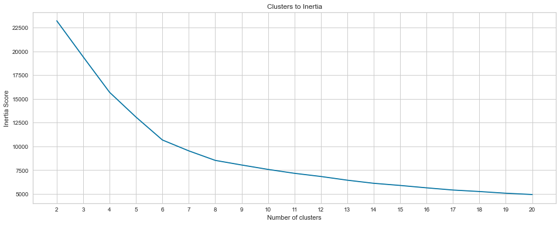

```python
# Creating the scree plot for Intertia - elbow method
fig, (ax1) = plt.subplots(1, figsize=(16,6))
num = np.arange(len(no_of_clusters))
ax1.plot(num, inertia)
ax1.set_xticks(num)
ax1.set_xticklabels(no_of_clusters)
plt.xlabel('Number of clusters')
plt.ylabel('Inertia Score')
plt.title("Clusters to Inertia")
plt.show()
```

Graphing the plots from above

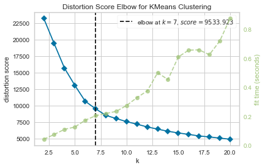

```python
model = KMeans()
# k is range of number of clusters.
visualizer = KElbowVisualizer(model, k=(2,21), timings= True,figsize=(16,6))
visualizer.fit(newdf)        # Fit data to visualizer
visualizer.show()        # Finalize and render figure
```

From all these plots, we can see that the optimal number of clusters is 7.

## Part V: Data Summary and Implications

KMeans is an unsupervised learning algorithm, and therefore we can not get a traditional accuracy measure through an accuracy score. We can measure the accuracy by the distortion score to clusters and fit time in the graphs from above. We can see that at the 7 cluster mark we hit the "Elbow" and from then on thr fit time rises dramatically. We can also see in the cluster to inertia graphs and charts that between 2 and 7 clusters there is the largest drop in inertia, and then from 8 on, the inertia starts slowly trailing off. This shows that the most influential clusters are the first 7, and then the accuracy starts dropping off. This shows that we could accurately predict with models using 7 clusters.

A real world organization could use this type of analysis to predict the principal variables of its customers with sufficient accuracy, however, they would need to make sure to run many more tests with different numbers and different data to get more accurate results.